# Who Checks the Hate Speech Scammers?Oops, I Mean ‘Monitors’

Labour handed a multi-million-pound contract to a body set up by two Muslim foundations, let its chief executive help write the definition of anti-Muslim hatred, and then watched it put mosque-attack figures on national television that, by its own admission, were not finished.

**Steve English** · Independent British writer and editor · 28 October 2026

- The British Muslim Trust’s claim that “a mosque is attacked every five days” ran on ITV and across the media.
- When The Spectator checked the cases behind it, about a third were plainly false — including an antisemitic arson on a former synagogue.
- BMT’s chief executive sat on the Government panel that wrote the definition of anti-Muslim hatred. Its advice to ministers was kept private.
- BMT admitted its report and methodology were not finished — two months after its headline figure first hit the news.
- The taxpayer pays. Nobody independent checks.

**PURPOSE:** To show how public money funds faith-lobby “hate monitors” that count their own grievances, help write the definitions they count against, and answer to nobody — and to demand that ministers stop it.

“A mosque is attacked every five days.”

It is a frightening sentence. It is meant to be. It came from the [British Muslim Trust](https://britishmuslimtrust.co.uk/research/a-year-of-division), Labour’s official monitor of anti-Muslim hatred. It went out through [Novara Media in July](https://novaramedia.com/2026/07/24/one-mosque-attacked-every-five-days-in-the-uk-new-data-shows/), then onto [ITV News on 25 September](https://www.itv.com/news/2026-09-25/i-feel-like-a-moving-target-attacks-on-muslim-sites-getting-worse-data-shows), and it was tied to [demands for more mosque security funding](https://www.newarab.com/news/one-uk-mosque-attacked-every-5-days-security-funding-stalls).

So who checked it? Not the police. Not an auditor. Not the department that pays for it. The only people who checked it were the people who counted it.

## Who they are

The British Muslim Trust did not exist until 2025. It was put together by two Muslim charities — the Aziz Foundation and the Randeree Charitable Trust. Shabir Randeree chairs the board. Akeela Ahmed is the chief executive.

In July 2025 Labour’s Minister for Faith, Lord Khan, [appointed BMT as the Government’s official partner](https://www.gov.uk/government/news/british-muslim-trust-appointed-as-new-partner-to-monitor-and-tackle-anti-muslim-hatred) to record anti-Muslim incidents, replacing Tell MAMA. The [funding prospectus](https://www.gov.uk/government/publications/combatting-hate-against-muslims-fund-prospectus/combatting-hate-against-muslims-fund-prospectus) set aside up to £650,000 for 2025–26 and up to £1 million for each of the next two years. [UnHerd reported](https://unherd.com/newsroom/islamophobia-watchdog-role-given-to-prevent-critic-2/) the contract at £2.5 million. The same report noted the Aziz Foundation had said in 2021 that Prevent — Britain’s counter-extremism programme — “actively harms Muslims.”

That is the organisation Labour chose to tell the country how much anti-Muslim hatred there is.

## Marking their own homework

In February 2025 Angela Rayner set up a five-member [working group to define anti-Muslim hatred and “Islamophobia”](https://www.gov.uk/government/groups/working-group-on-anti-muslim-hatredislamophobia-definition). Akeela Ahmed was one of the five.

The group had six months. Before it had finished, in July 2025, the Government named Akeela Ahmed as the incoming chief executive of the British Muslim Trust.

Read that again. The same person helped write the definition of anti-Muslim hatred and now runs the taxpayer-funded body paid to count incidents against it.

And the public was not allowed to see the working. The group’s [terms of reference](https://data.parliament.uk/DepositedPapers/Files/DEP2025-0213/Anti-Muslim_Hatred_Islamophobia_Definition_Working_Group_ToR.pdf) said its advice was for ministers only and would not be made public. The Government has since adopted a definition built on that private advice.

The definition was written behind closed doors. The counting is done behind closed doors. The bill goes to you.

## The numbers fall apart

BMT says it recorded 78 attacks on mosques in a year. On 9 October, [Andrew Gilligan of The Spectator](https://spectator.com/?p=692487) went through the cases BMT had listed — about 40 of them. Roughly a third were plainly false. Here is what was being counted as an “attack on a mosque”:

- **An antisemitic arson on a former synagogue.** The former East London Central Synagogue on Nelson Street was set alight on 5 May 2026. Tower Hamlets’ own mayor, Lutfur Rahman, [condemned it as an “appalling antisemitic attack.”](https://www.towerhamlets.gov.uk/News_events/2026/May/Mayor-of-Tower-Hamlets-condemns-antisemitic-arson-attack-on-former-synagogue.aspx) BMT put it in its anti-Muslim total.
- **A fire police said was not religiously motivated.** An outbuilding at a Worcester community centre was set alight in February. [Police said](https://www.aol.com/articles/murder-arrest-mans-body-found-141103986.html) there was “no information to suggest” a racial or religious motive, and [West Mercia Police](https://www.westmercia.police.uk/news/west-mercia/news/2026/february/incidents-believed-to-be-linked-to-worcester-murder/) linked the incidents to a murder inquiry and a dispute within the homeless community. BMT counted it.
- **A stabbing that never went near a mosque.** In Edinburgh in June, an attacker started in a park a quarter of a mile from the nearest mosque and moved on to shops, takeaways and a petrol station. Counted as a mosque attack.
- **Muslims protesting against Iran’s regime.** Protests outside a Glasgow Islamic centre, many by anti-regime Iranians, were logged as anti-Muslim targeting.
- **Mosques that do not exist yet.** A mostly peaceful protest against a planned mosque in Dalton, Cumbria, and a residents’ leafleting campaign against a proposed Islamic complex in Harefield. Neither site is operating as a mosque. Both counted.
- **Plots that never happened.** Two foiled plots were counted as attacks.
- **Letters and posts.** Online abuse of a scholar, an abusive letter to an imam, and a false Facebook post about an imam in Belfast were all counted as attacks on mosques.

If a third of a company’s accounts turned out to be fiction, nobody would describe the rest as “verified.” BMT does.

## Broadcast first, method later

When The Spectator put questions to BMT between 30 September and 2 October, BMT’s [own published response](https://britishmuslimtrust.co.uk/statements/bmt-response-to-the-spectator-article) says it told the journalist the report — including its underlying methodology — was not finished.

Not finished. Yet the “every five days” figure was on Novara in July and on ITV in September.

BMT put the conclusion on national television first and was still building the method that produced it. That is not monitoring. That is campaigning with a government logo on it.

## How a phone call becomes a statistic

BMT runs a hotline and an online form. Victims can report. So can witnesses. The Muslim Council of Britain, welcoming BMT’s appointment, [urged police forces and the Home Office to take in BMT’s anonymous incident data](https://mcb.org.uk/?p=38930).

Then look at BMT’s definitions. As [The Spectator set out](https://spectator.com/?p=692487), a “mosque” includes the people and communities connected to it, and an “attack” includes alleged plots and incidents reported by the person who perceived them as hate.

Put those together. A witness can report something overheard between two strangers, about a person connected to a mosque, which they perceived as hate — and it can end up in a national figure for attacks on mosques, quoted on the evening news.

And the checking? This sector has told us how it checks. When Tell MAMA defended its own figures in 2013, it said its second stage of verification involved contacting [“relatives and witnesses of the victim.”](https://tellmamauk.org/?p=637) In other words, the check on a complaint is a conversation with the complainant’s family and friends. A brother, an aunt, a fellow worshipper — each one another “witness.”

BMT has published no case-by-case evidence trail for its 78. We are simply expected to believe it.

## We have been here before

In 2013 Tell MAMA claimed a “wave” of 212 anti-Muslim incidents after the murder of Drummer Lee Rigby. [Andrew Gilligan, then at the Sunday Telegraph](https://www.meforum.org/islamist-watch/tell-mama-did-exaggerate-anti-muslim-attacks-pcc), found that 57 per cent had taken place only online, mostly offensive posts on Twitter and Facebook. He then [reported](https://www.meforum.org/islamist-watch/muslim-hate-monitor-to-lose-backing) that its public funding was not renewed after officials raised concerns about its methods. Tell MAMA’s founder complained to the press regulator. The complaints were rejected.

Thirteen years later: a new name, the same model, the same journalist finding the same problems — and a bigger cheque.

## Fund your own monitors

The police already record hate crime. That is their job, and they answer to courts, inspectors and the law.

If any faith group — Muslim, Jewish, Christian or any other — wants a hotline to log insults to its religion and its followers, it is free to pay for one. What it should not get is public money, an official stamp, a seat at the table writing the definitions, and figures that ministers and broadcasters repeat as fact.

A definition of anti-Muslim hatred, drafted in private by people who now run the body that enforces it, is not hate-crime policy. It is a blasphemy code by another name — and the taxpayer is paying to run it.

Opinion

## Our verdict

On the evidence above, we say this is a racket dressed as a public service. A sector is paid to produce frightening numbers. The numbers are used to demand more money and tighter rules on what can be said. The same people help write those rules. Nobody outside the sector checks any of it. That is why our headline calls them scammers — and why the word stays.

## What Labour must do now

1. Publish every case behind BMT’s 78 “attacks,” with the evidence relied on for each, with victims’ names removed.
2. Publish the grant agreement and every payment made to BMT to date.
3. Publish the working group’s advice to ministers in full.
4. Commission an independent audit of BMT’s figures by someone with no connection to the sector.
5. Freeze further payments until that audit is done.

Labour bought these numbers with your money. Labour should have to prove they are true.

## Want to Dive Deeper? Official sources you can link:

1. British Muslim Trust — “A Year of Division” report.https://britishmuslimtrust.co.uk/research/a-year-of-division
2. British Muslim Trust — published response to The Spectator.https://britishmuslimtrust.co.uk/statements/bmt-response-to-the-spectator-article
3. Andrew Gilligan, The Spectator, 9 October 2026 — “The British Muslim Trust’s mosque attack claims don’t add up.”https://spectator.com/?p=692487
4. GOV.UK, 21 July 2025 — British Muslim Trust appointed as new partner to monitor and tackle anti-Muslim hatred.https://www.gov.uk/government/news/british-muslim-trust-appointed-as-new-partner-to-monitor-and-tackle-anti-muslim-hatred
5. GOV.UK — Combatting Hate Against Muslims Fund prospectus.https://www.gov.uk/government/publications/combatting-hate-against-muslims-fund-prospectus/combatting-hate-against-muslims-fund-prospectus
6. UnHerd, 23 July 2025 — Islamophobia watchdog role given to Prevent critic.https://unherd.com/newsroom/islamophobia-watchdog-role-given-to-prevent-critic-2/
7. GOV.UK — Working Group on Anti-Muslim Hatred/Islamophobia Definition: membership.https://www.gov.uk/government/groups/working-group-on-anti-muslim-hatredislamophobia-definition
8. House of Commons deposited paper — Working Group terms of reference.https://data.parliament.uk/DepositedPapers/Files/DEP2025-0213/Anti-Muslim_Hatred_Islamophobia_Definition_Working_Group_ToR.pdf
9. Tower Hamlets Council, 5 May 2026 — Mayor condemns antisemitic arson attack on former synagogue.https://www.towerhamlets.gov.uk/News_events/2026/May/Mayor-of-Tower-Hamlets-condemns-antisemitic-arson-attack-on-former-synagogue.aspx
10. West Mercia Police, February 2026 — incidents believed to be linked to Worcester murder.https://www.westmercia.police.uk/news/west-mercia/news/2026/february/incidents-believed-to-be-linked-to-worcester-murder/
11. Report of 26 February 2026 — police statement on the Worcester community centre fire.https://www.aol.com/articles/murder-arrest-mans-body-found-141103986.html
12. ITV News, 25 September 2026 — attacks on Muslim sites.https://www.itv.com/news/2026-09-25/i-feel-like-a-moving-target-attacks-on-muslim-sites-getting-worse-data-shows
13. Novara Media, 24 July 2026 — “One Mosque Attacked Every Five Days.”https://novaramedia.com/2026/07/24/one-mosque-attacked-every-five-days-in-the-uk-new-data-shows/
14. The New Arab — figure used in calls for security funding.https://www.newarab.com/news/one-uk-mosque-attacked-every-5-days-security-funding-stalls
15. Muslim Council of Britain — statement on BMT’s appointment and anonymous data sharing.https://mcb.org.uk/?p=38930
16. Tell MAMA, 2 June 2013 — “Gilligan & the Reductionists” (its own account of verification).https://tellmamauk.org/?p=637
17. Andrew Gilligan, Sunday Telegraph, 2013 — Muslim hate monitor to lose backing (republished).https://www.meforum.org/islamist-watch/muslim-hate-monitor-to-lose-backing
18. Andrew Gilligan, Sunday Telegraph — Press Complaints Commission rejects Tell MAMA complaints (republished).https://www.meforum.org/islamist-watch/tell-mama-did-exaggerate-anti-muslim-attacks-pcc

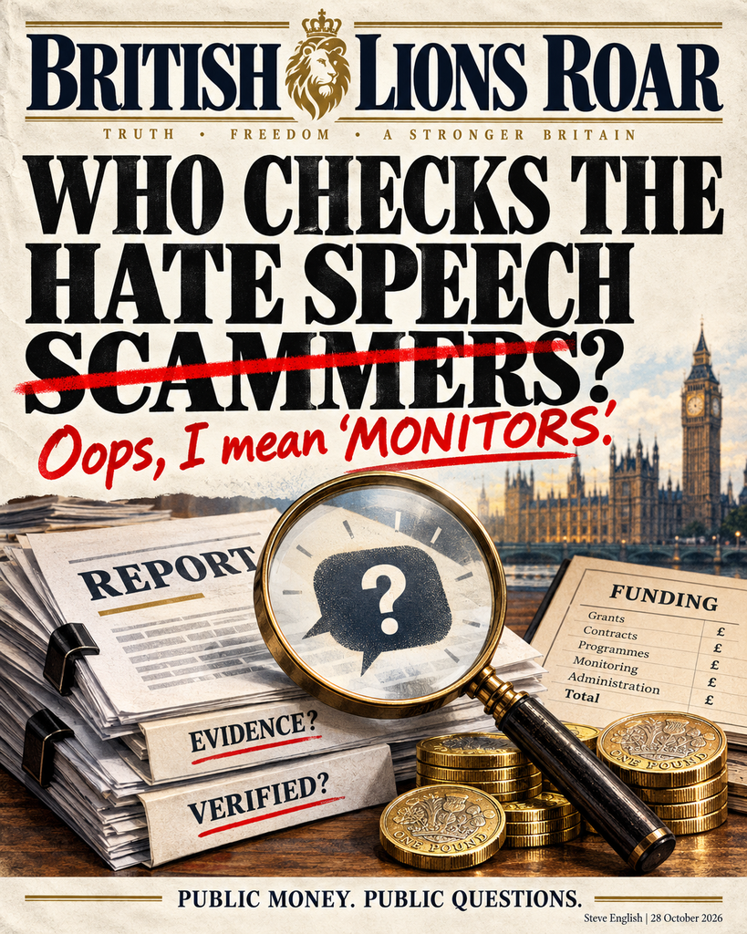